# ESC 2015

~

2019-10-28

## Introduction

I’m going to present some preliminary findings from my PhD thesis looking at criminal careers and their relationship with the crime drop in Scotland, focusing particularly on the relationship between the type of first offence and subsequent patterns of criminal careers. You may notice a slight change in the title compared to my abstract to better reflect what I’ve been doing, which reflects the status of this research as very much work in progress – so any feedback, especially about methods used, would be very much appreciated. I’m going to give a bit of background to the project, outline my aims and research question, the data and methods used to answer this research question and then present and discuss the preliminary results.

## Lit review

So, why look at this topic? Interest in using type of first offence as a predictor of criminal careers is based on the ‘début crime hypothesis’ and the ‘keystone crime’ hypothesis. The début crime hypothesis suggests that offenders often commit burglary and car theft at the start of their criminal careers before progressing on to other crimes. The keystone crime hypothesis contends that car theft in particular allows offenders to commit other kinds of crime, by increasing a person’s mobility and potentially providing a method by which to transport stolen goods.

These hypotheses have been suggested as part of a wider securitization thesis to explain how declines in crimes of dishonesty may have led to declines in other types of crime. These specific hypotheses link declines in crimes of dishonesty with declines in other types of crime: with fewer people starting criminal careers due to declines in début crimes, fewer people go on to continue criminal careers. These hypotheses then, link our understanding of criminal careers to the mechanisms driving the crime drop.

These hypotheses are derived from work by Svensson (2002) using convictions data Sweden and subsequently Owen and Cooper (2013) using convictions data from England and Wales who show that people whose first convictions are for robbery, vehicle theft or burglary are more likely to go on to be ‘chronic’ offenders than those with first convictions for other crime types.

Key to this research are the outcome measured used. Both investigations defined ‘chronic’ status relative to the total number of convictions received, with Svensson using a cut-off of nine offences over an eight-year period and Owen and Cooper using a cut-off of 15 or more re-offences in a five-year period. Using a different outcome measures and self-report data, DeLisi and colleagues found that type of first offence from a sample of arrestees to predict three different measures of criminal careers the total number of arrests, being more than one standard deviation above the mean number of arrests - what they term “extreme chronicity”, and the rate of offending per year. They found that only a first offences for drugs use was predictive of all three outcomes, whilst car theft was predictive of offending rate.

This is the setting up the problem bit The measures used in these previous studies have two limitations. First, as they use general measures of crime, they cannot tell us about the relationship between the type of first offence and the type of a person’s future offending. The very point of looking for ‘strategic’ or ‘début’ crimes implies moving from one type of crime to another during a person’s criminal career.

Second, the ex ante cut off points between chronic and non-chronic offenders used by Svensson and Owen and Cooper are subjective (Nagin 2004). This may make the observed results a function of the cut-points chosen. An alternative approach to classifying individuals into different groups based on their offending patterns is methodological (Nagin and Land 1993, Nagin 2004). Most commonly this involves methods based on latent class analysis (McCutcheon 1987). In LCA the number and the nature of groups identified are determined statistically, as opposed to the researcher specifying a demarcation between groups. Latent class methods can also incorporate different types of crime as an outcome measure (Soothill et al. 2008). I’m not going to say too much about how LCA works, but please feel free to ask any questions about that afterwards.

## Aims and RQ

So, the current study aims to investigate the impact of the type of first offence on future criminal careers measured by membership of different latent offending classes. This will add to our understanding of the relationship between the type of first offence and subsequent criminal careers patterns using a measure of criminal careers not previously used for this purpose. The research questions focus this aim on examining the distribution of first offences among the chronic offender class an assessing the size of this relationship.

## Data and Methods

To do this, I analyse administrative data from the Scottish Offenders Index (SOI). SOI contains a record of every individual convicted in Scottish courts between 1st January 1989 and 31st August 2013, with the exception of those convicted for motoring offences and some crimes against public justice, the details of the offence and conviction as well as the person’s age and sex. The data covers individuals from the age of 16. SOI only contains records of the most serious conviction in a particular hearing and this means it likely underestimates the volume of offending by a particular person, and, as ever, not all offences committed are convicted. However, they provide a reliable source of data on the type of most serious crime committed, and timings and sequencing of offences may be more reliable than in self-report data reference.

Once groups have been identified by latent class analysis we can assess the distribution of first offences within groups. Classes are estimated using the whole dataset, but today I’m just going to focus on the first age band, covering the years 16-20, around ~140,000 age bands. At this stage I’m using descriptive statistics to do this.

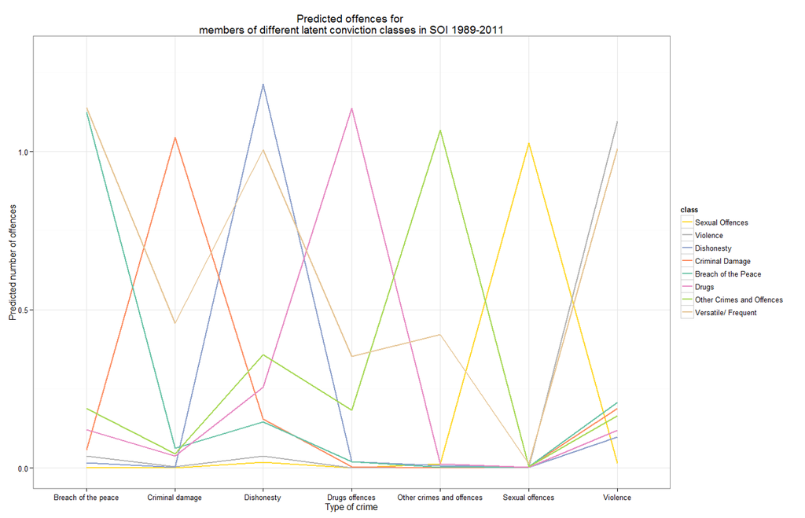

Latent classes

One other feature to note is the entropy of this final model was over 0.9, suggesting that the groups identified are very distinct. Based on this high entropy value I use most likely class as the indicator of class membership. Whilst this approach introduces measurement error, it was considered acceptable given this high entropy value (Clark and Muthén 2009). At this stage I haven’t accounted for this error, so we need to bear this in mind when interpreting the results.

## Discussion

We should note that these results in no way invalidate the securitization thesis, or suggest that better security measures have had no impact on declining crime rates. However, they do suggest that the impact of début and keystone crimes on patterns of criminal careers is unlikely to have led to large scale declines in overall offending given its small effect size.

## Limitations

There are, as ever, some caveats to these results. These results relate to only one case (Scotland), and one age-band (ages 16-20) and the data-driven method of analysis complicates generalization to other cases. Replication is required to affirm whether these results will hold true in other cases. Methodologically, the methods used here could be expanded on (for example, by including covariates in the latent class model or using logistic regression to assess the relationship between first offence and offending class). This may be an area in which to develop this research.

## Conclusions and next steps

Despite these limitations this research presents a valuable contribution to our understanding of the impact of the type of first offence on criminal careers. Using an outcome measure not previously used for this purpose, this research has affirm the findings of existing studies which show that début crime is statistically related to chronic offending. However, the ‘effect size’ of this relationship is small, questioning its substantive significance and the possible role of declines in the type of first offence as playing a substantial role in reducing overall crime.